# CO2 data and ANOVA

Scott Pitz

October 20, 2017

## CO2 data and running ANOVAs

I downloaded this data from the NOAA website https://www.esrl.noaa.gov/gmd/ccgg/trends/data.html and cleaned it a little for you.

If you were to use your own data, you should organize it in excel and then save it as a .csv file to your working directory.

The data are CO2 concentrations from flask samples taken at Mauna Loa, a site called the Southern Great Plains in Oklahoma and the South Pole.

ok cool. Let’s start building your program. Copy the following code in to a new R script and run it. You should be able to copy the code from this webpage, paste it into an R script, run it, and compare it with the output on the webpage.

```r
# Clear workspace

rm(list=ls(all=T))

#this loads a package that has already been installed
library(ggplot2) #once its been loaded, you can use the functions it provides
```

Go ahead and read in the data from the csv files:

```r
#set your working directory for your computer
setwd("C:/Users/Pitz/Desktop/")
#setwd("/Users/Pitz/Desktop/") #your path to your working directory will look more like this if you use a mac
# Read in data
loa<- read.csv("ML CO2.csv") #read in csv file
OK<- read.csv("south plains OK.csv") #read in csv file
southPole<- read.csv("spo co2.csv") #read in csv file
```

Take a look at the top of each of the csv files and note the column names.

```r
head(loa)
```

```
##   year month MLconc
## 1 1969     8 322.51
## 2 1969     9 321.36
## 3 1969    10 320.74
## 4 1969    11 321.98
## 5 1969    12 323.78
## 6 1970     1 325.13
```

```r
colnames(loa)
```

```
## [1] "year"   "month"  "MLconc"
```

```r
head(OK)
```

```
##   year month OKconc
## 1 2002     4 377.55
## 2 2002     5 374.78
## 3 2002     6 374.24
## 4 2002     7 372.72
## 5 2002     8 368.48
## 6 2002     9 370.24
```

```r
colnames(OK)
```

```
## [1] "year"   "month"  "OKconc"
```

```r
head(southPole)
```

```
##   year month Spconc
## 1 1975     7 329.39
## 2 1975     8 329.86
## 3 1975     9 330.05
## 4 1975    10 330.27
## 5 1975    11 330.47
## 6 1975    12 330.08
```

```r
colnames(southPole)
```

```
## [1] "year"   "month"  "Spconc"
```

## Add a new column

So we should take a look at our data but the format of the data is that there are 12 data points for each year. If we create a graph in ggplot using the year column, they will all have data points at the same x value. To fix this, let’s create a new column in each of the dataframes called decYear, that incorporates the month. Then we should check to makes sure it worked by running the head() command.

```r
loa$decYear <- loa$year +loa$month/12
OK$decYear <- OK$year +OK$month/12
southPole$decYear <- southPole$year +southPole$month/12

head(loa)
```

```
##   year month MLconc  decYear
## 1 1969     8 322.51 1969.667
## 2 1969     9 321.36 1969.750
## 3 1969    10 320.74 1969.833
## 4 1969    11 321.98 1969.917
## 5 1969    12 323.78 1970.000
## 6 1970     1 325.13 1970.083
```

## Start building a plot

Let’s plot up our Mauna Loa data first. We will create a ggplot object called co2plot, plot the datapoints and a red line that connects them. Note that the red line plots on top of the data points.

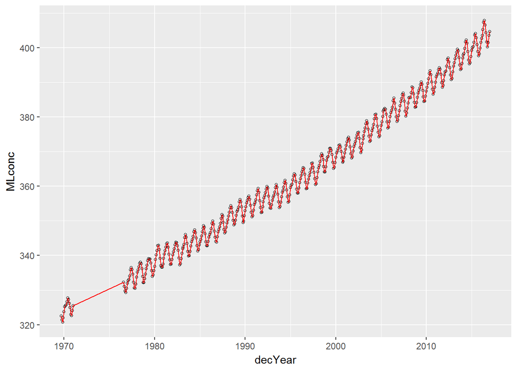

```r
co2plot <- ggplot(loa, aes(decYear, MLconc))+ #dataframe, x, y
  geom_point(shape=1, size= 1)+ #adds points, circles
  geom_line(color="red") #add line

co2plot
```

## Change the plot labels

Ok, not bad, but lets see if we can beautify the plot and its labels. The following chunk of code changes the plot labels.

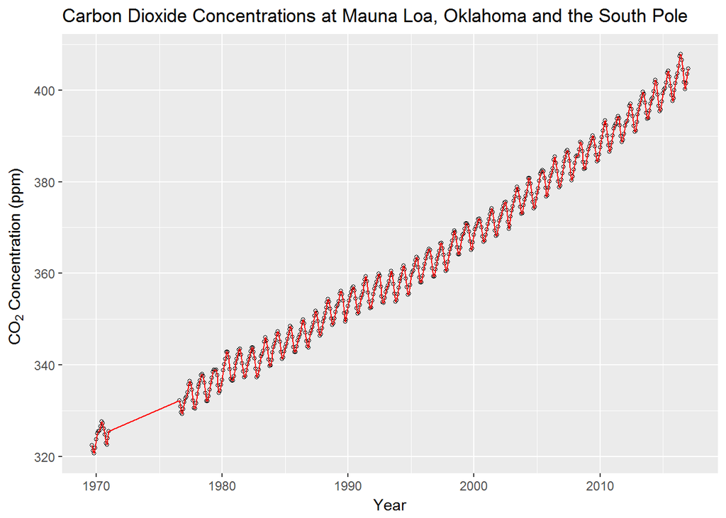

```r
co2plot <- co2plot + labs(x="Year",
                          y=expression(paste(CO[2]," Concentration (ppm) ", sep="")),
                          title = "Carbon Dioxide Concentrations at Mauna Loa, Oklahoma and the South Pole")

co2plot
```

## Change the plot label size

Better, but we should make the plot labels a little more readable. Also, the theme_bw() option looks a little more professional and closer to publishable quality.

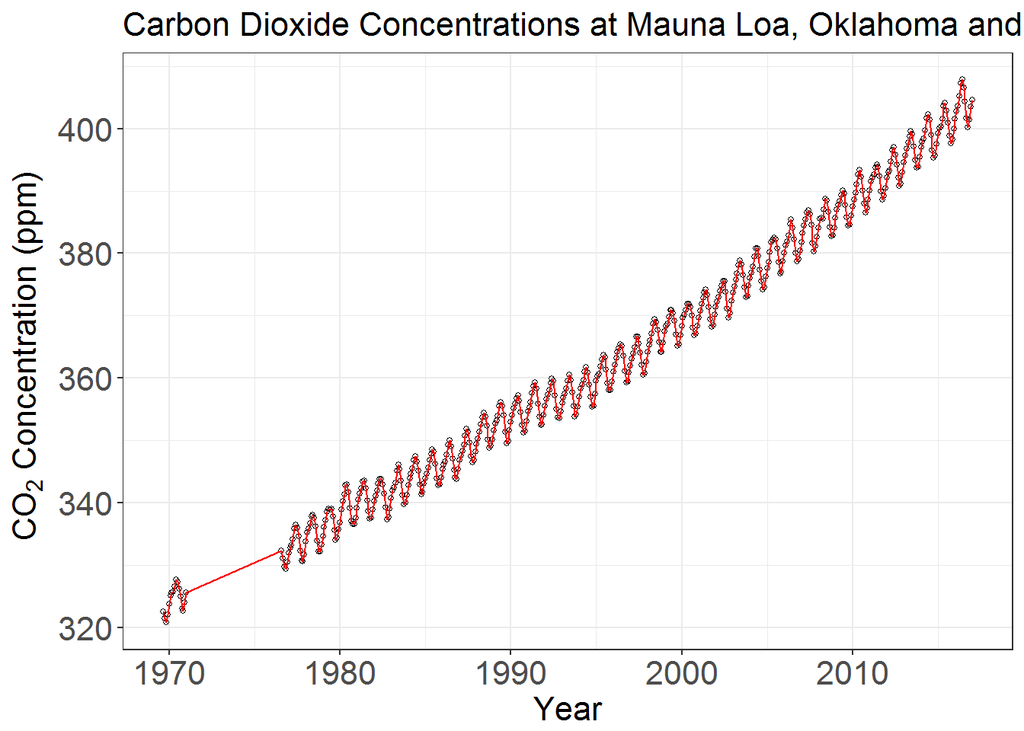

```r
co2plot <- co2plot +
  theme_bw() +
  theme(plot.title = element_text(size=16),
        axis.text.x  = element_text(size=16),
        axis.title.x = element_text(size=16),
        axis.title.y = element_text(size=16),
        axis.text.y  = element_text(size=16))

co2plot
```

## Add the other datasets

Time to make the title true. Lets add the other data sets to the plot

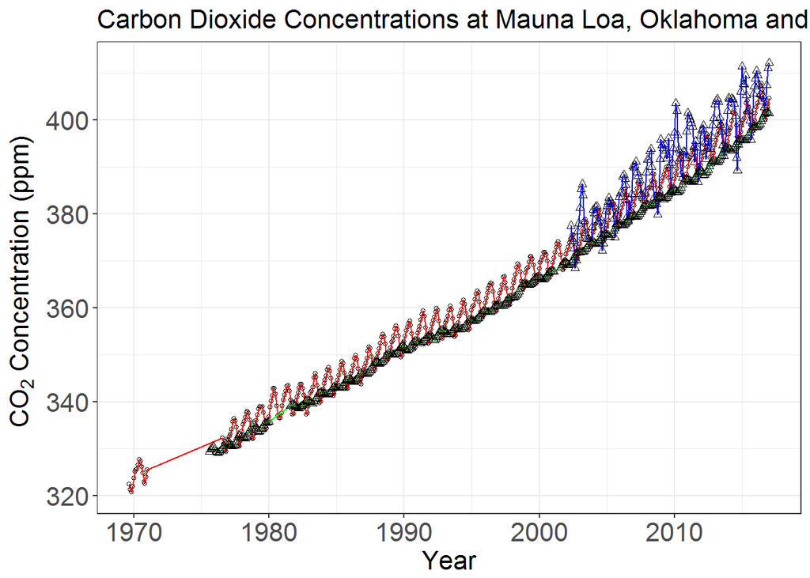

```r
co2plot <- co2plot +
  geom_point(data=OK, aes(x=decYear, y=OKconc), shape=2)+
  geom_line(data=OK, aes(x=decYear, y=OKconc), color="blue")+
    geom_line(data=southPole, aes(x=decYear, y=Spconc), color="green")+
  geom_point(data=southPole, aes(x=decYear, y=Spconc), shape=2)

co2plot
```

## Adjust the plot limits

The plot looks a little crowded and dense. We can change our view and zero in on the time period where we have data from Oklahoma.

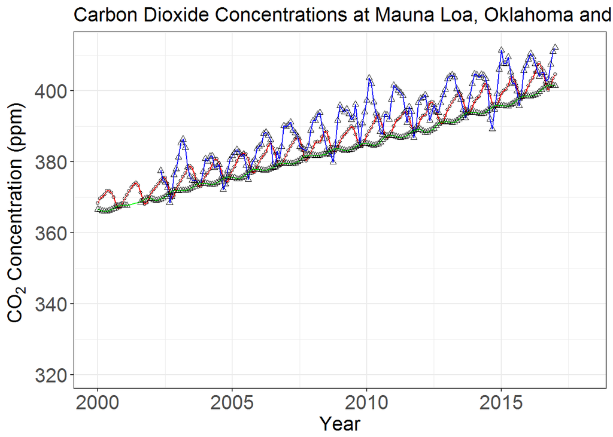

```r
co2plot + xlim(2000, 2018)
```

## Adjust the plot limits, y-axis

Better, but let’s narrow the y-axis limits.

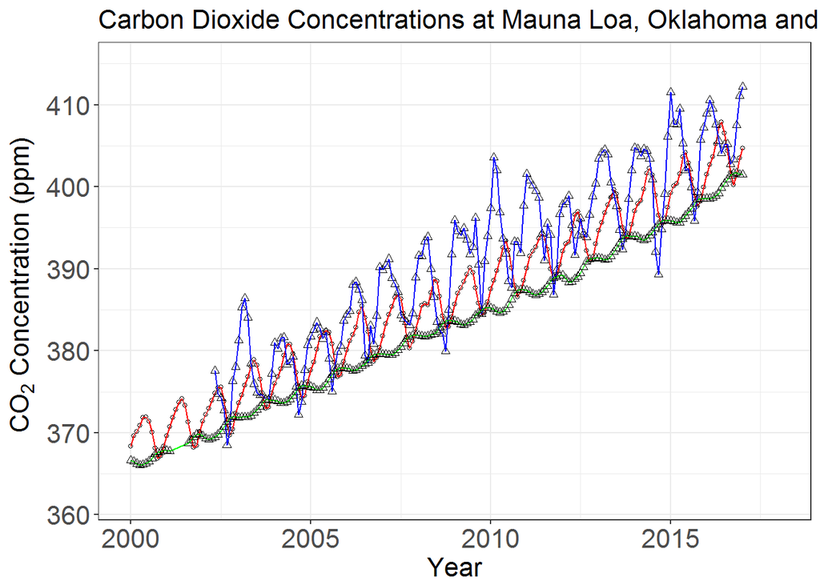

```r
co2plot + xlim(2000, 2018)+ylim(362, 415)
```

## Subset the data

Great, now we can easily see our data.

Relative to Mauna Loa, we can see the Oklahoma data is noisy, and the South Pole data has a pretty low seasonal amplitude. Interesting…

To further dig into the data we should try to subset and merge the data sets together.

Let’s try to test if the average values from certain years, at different sites, specifically 2009 and 2010, are significantly different from each other.

First, lets subset each of the datasets into new dataframes that only have 2009 and 2010 data in them.

```r
#subset the data
#newdataframe <- olddataframe[olddataframe$variable == something,]
loa2009 <- loa[loa$year==2009 | loa$year==2010,] # the | symbol means "or"
ok2009 <- OK[OK$year==2009 | OK$year==2010,] # so we want data that is from 2009 "or" 2010
sp2009 <- southPole[southPole$year==2009 | southPole$year==2010,]

loa2009
```

```
##     year month MLconc  decYear
## 408 2009     1 386.97 2009.083
## 409 2009     2 387.71 2009.167
## 410 2009     3 388.41 2009.250
## 411 2009     4 389.34 2009.333
## 412 2009     5 390.11 2009.417
## 413 2009     6 389.52 2009.500
## 414 2009     7 387.71 2009.583
## 415 2009     8 385.84 2009.667
## 416 2009     9 384.44 2009.750
## 417 2009    10 384.60 2009.833
## 418 2009    11 386.00 2009.917
## 419 2009    12 387.51 2010.000
## 420 2010     1 388.59 2010.083
## 421 2010     2 389.72 2010.167
## 422 2010     3 391.07 2010.250
## 423 2010     4 392.60 2010.333
## 424 2010     5 393.37 2010.417
## 425 2010     6 392.25 2010.500
## 426 2010     7 390.09 2010.583
## 427 2010     8 388.00 2010.667
## 428 2010     9 386.55 2010.750
## 429 2010    10 387.21 2010.833
## 430 2010    11 388.57 2010.917
## 431 2010    12 390.06 2011.000
```

```r
summary(loa2009)
```

```
##       year          month           MLconc         decYear
##  Min.   :2009   Min.   : 1.00   Min.   :384.4   Min.   :2009
##  1st Qu.:2009   1st Qu.: 3.75   1st Qu.:387.1   1st Qu.:2010
##  Median :2010   Median : 6.50   Median :388.5   Median :2010
##  Mean   :2010   Mean   : 6.50   Mean   :388.6   Mean   :2010
##  3rd Qu.:2010   3rd Qu.: 9.25   3rd Qu.:390.1   3rd Qu.:2011
##  Max.   :2010   Max.   :12.00   Max.   :393.4   Max.   :2011
```

## Add a column, same value

Looks good. We can use the summary() command to get summary statistics about each of our columns. For example, you can see that the mean value of concentration from loa2009 was 388.6 ppm. Those summary statistics can be used to create something called a boxplot. We will create a boxplot from our data in a moment.

But before we do that we need to merge our dataset together, and before we can do that we need to do two things; add a site name column and make sure all the column names are the same.

We have created new, calculated columns before but we also create new columns with a single value in it.

```r
#add column, with one value
ok2009$site <- "OK"
loa2009$site <- "ML"
sp2009$site <- "SP"

head(sp2009)
```

```
##     year month Spconc  decYear site
## 380 2009     1 383.51 2009.083   SP
## 381 2009     2 383.19 2009.167   SP
## 382 2009     3 383.16 2009.250   SP
## 383 2009     4 383.37 2009.333   SP
## 384 2009     5 383.53 2009.417   SP
## 385 2009     6 383.84 2009.500   SP
```

## Change column name

The head(sp2009) command shows us we sucessfully added the site column.

To combine the dataset we are going to do what is called a vertical merge. But for that to work all the columns have to have the exact same name. This is case sensitive. Right now, each of our concentration columns have a slightly different name.

We can change that by renaming those columns, with the following commands. We know that the concentration data is in the third column, which is why the number in the square brackets is “3”.

```r
#change variable names
head(loa2009)
```

```
##     year month MLconc  decYear site
## 408 2009     1 386.97 2009.083   ML
## 409 2009     2 387.71 2009.167   ML
## 410 2009     3 388.41 2009.250   ML
## 411 2009     4 389.34 2009.333   ML
## 412 2009     5 390.11 2009.417   ML
## 413 2009     6 389.52 2009.500   ML
```

```r
colnames(loa2009)[3] <- "conc"
colnames(ok2009)[3] <- "conc"
colnames(sp2009)[3] <- "conc"

head(loa2009)
```

```
##     year month   conc  decYear site
## 408 2009     1 386.97 2009.083   ML
## 409 2009     2 387.71 2009.167   ML
## 410 2009     3 388.41 2009.250   ML
## 411 2009     4 389.34 2009.333   ML
## 412 2009     5 390.11 2009.417   ML
## 413 2009     6 389.52 2009.500   ML
```

## Vertical merge or rbind

Now we are all set to merge the subsets of data into a new dataframe. Once we do this we can make some boxplots and run an ANOVA.

```r
#verge subsets into new dataframe
vertMergeSite <- rbind(loa2009, ok2009, sp2009)
```

## Boxplots

Let’s make our boxplots.

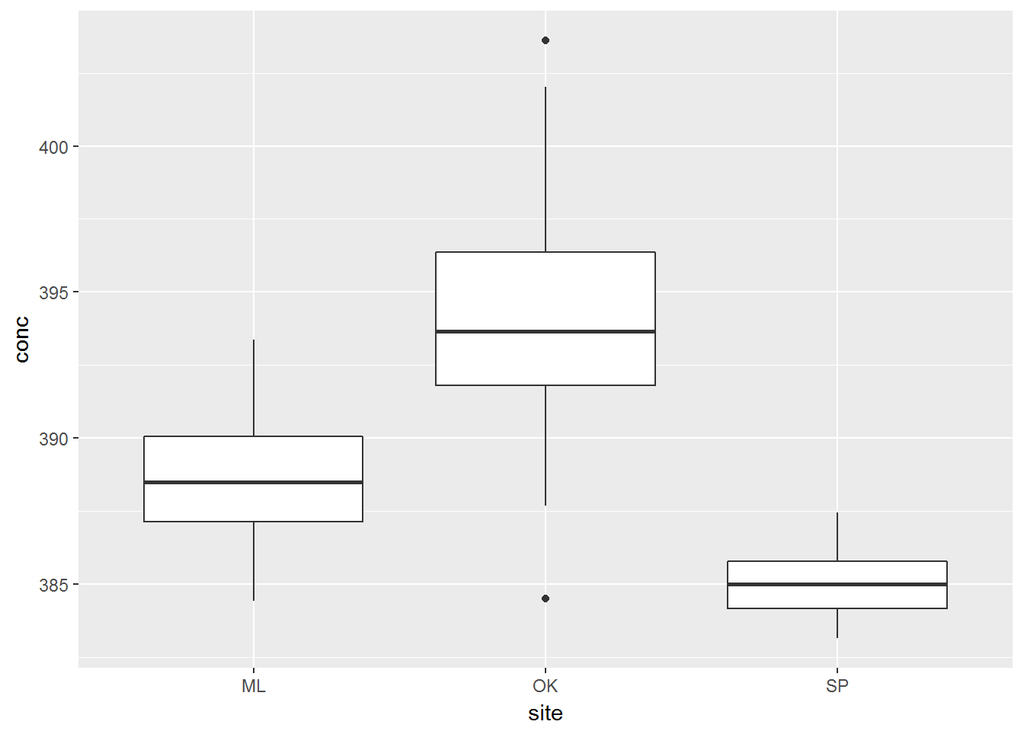

```r
p <- ggplot(vertMergeSite, aes(site, conc))+
  geom_boxplot()

p
```

You should look up the different parts of the boxplot yourself, but when they separate out like these do, its a good sign they may be significantly different.

And lets clean up the appearance like we know how.

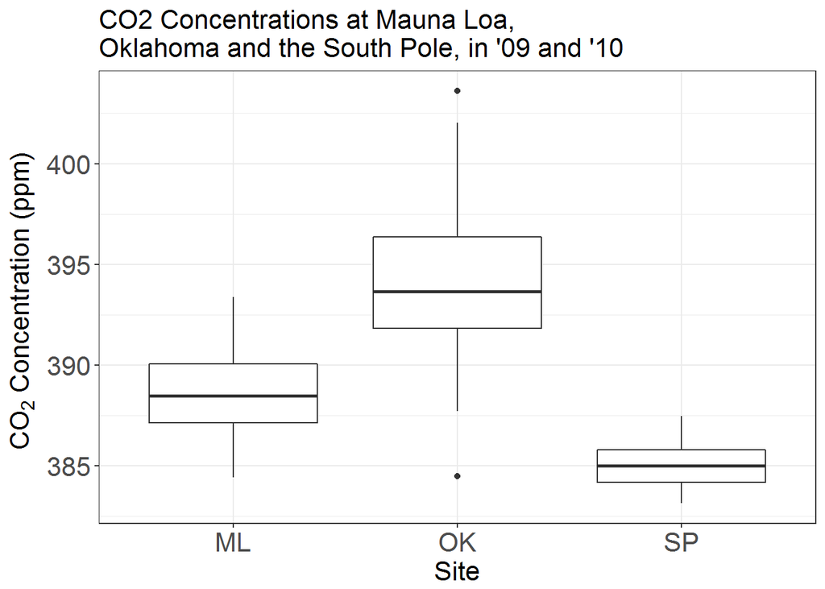

```r
p <- p + labs(x="Site",
              y=expression(paste(CO[2]," Concentration (ppm) ", sep="")),
              title = "CO2 Concentrations at Mauna Loa,
Oklahoma and the South Pole, in '09 and '10")+
  theme_bw() +
  theme(plot.title = element_text(size=16),
        axis.text.x  = element_text(size=16),
        axis.title.x = element_text(size=16),
        axis.title.y = element_text(size=16),
        axis.text.y  = element_text(size=16))

p
```

Now our data is all set up to run an ANOVA.

```r
fit <- aov(conc ~ site, data=vertMergeSite)

summary(fit)
```

```
##             Df Sum Sq Mean Sq F value  Pr(>F)
## site         2  971.7   485.8   53.68 8.7e-15 ***
## Residuals   69  624.5     9.1
## ---
## Signif. codes:  0 '***' 0.001 '**' 0.01 '*' 0.05 '.' 0.1 ' ' 1
```

We can get the mean, standard deviation and standard error from the summarySE() command.

```r
library(Rmisc)
summarySE(vertMergeSite, measurevar="conc", groupvars=c("site"))
```

```
##   site  N     conc       sd        se        ci
## 1   ML 24 388.5933 2.350759 0.4798466 0.9926384
## 2   OK 24 394.0500 4.436217 0.9055389 1.8732500
## 3   SP 24 385.1250 1.395053 0.2847641 0.5890794
```